# 1 Scikit-Learn Basics

## 1. 监督学习：回归算法

### 1.1 线性回归及非线性回归

**1.1.1 一元线性回归Unary linear regression**：一个自变量一个因变量  
代价函数Cost function：最小二乘法（使误差平方和最小）  
相关系数（线性关系强弱），决定系数（范围更广）  
梯度下降法Gradient descent：从初始值求导代价函数，使为零值并移动步长，迭代优化得到代价函数的全局最小值/局部极小值（近似解）  
（取合适大小的学习率，参数要同步更新）  
线性回归的代价函数是凸函数convex，最后会达到全局最小值，适用梯度下降法

```python
import numpy as np
import pandas as pd
import matplotlib.pyplot as plt
from sklearn import datasets
from mpl_toolkits.mplot3d import Axes3D
import pydotplus as pyd
from IPython.display import Image

from sklearn.preprocessing import PolynomialFeatures, StandardScaler
from sklearn.metrics import classification_report, confusion_matrix
from sklearn.model_selection import train_test_split, cross_val_score
from sklearn.feature_extraction.text import CountVectorizer, TfidfVectorizer

from sklearn.linear_model import LinearRegression, RidgeCV, LassoCV, ElasticNetCV, LogisticRegression
from sklearn.neighbors import KNeighborsClassifier
from sklearn.tree import DecisionTreeClassifier, export_graphviz
from sklearn.naive_bayes import BernoulliNB, MultinomialNB, GaussianNB
from sklearn.svm import SVC
from sklearn.neural_network import MLPClassifier
from sklearn.ensemble import BaggingClassifier, RandomForestClassifier, AdaBoostClassifier, VotingClassifier
from mlxtend.classifier import StackingClassifier
from sklearn.cluster import KMeans, MiniBatchKMeans, DBSCAN
from sklearn.decomposition import PCA
```

```python
df = pd.read_csv('data.csv',header=None)
df.head()
```

|  | 0 | 1 |
| --- | --- | --- |
| 0 | 32.502345 | 31.707006 |
| 1 | 53.426804 | 68.777596 |
| 2 | 61.530358 | 62.562382 |
| 3 | 47.475640 | 71.546632 |
| 4 | 59.813208 | 87.230925 |

```
Coefficient: [[1.32243102]]
Intercept [7.99102098]
```

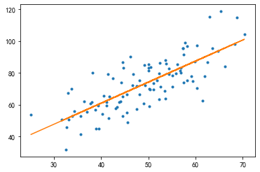

```python
X = df.iloc[:,0].values.reshape(-1,1)
y = df.iloc[:,1].values.reshape(-1,1)

linear = LinearRegression().fit(X, y)

print('Coefficient:', linear.coef_)
print('Intercept', linear.intercept_)
plt.plot(X, y, '.')
plt.plot(X, linear.predict(X))
plt.show()
```

**1.1.2 多元线性回归Multivariable linear regression**：多个自变量一个因变量

```python
df = pd.read_csv('Delivery.csv',header=None)
df.head()
```

|  | 0 | 1 | 2 |
| --- | --- | --- | --- |
| 0 | 100 | 4 | 9.3 |
| 1 | 50 | 3 | 4.8 |
| 2 | 100 | 4 | 8.9 |
| 3 | 100 | 2 | 6.5 |
| 4 | 50 | 2 | 4.2 |

```
Coefficient: [[0.0611346  0.92342537]]
Intercept [-0.86870147]
```

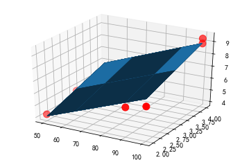

```python
X = df.iloc[:,:-1].values
y = df.iloc[:,-1].values.reshape(-1,1)

linear = LinearRegression().fit(X, y)

print('Coefficient:', linear.coef_)
print('Intercept', linear.intercept_)

x0 = df.iloc[:,0]
x1 = df.iloc[:,1]

ax = plt.figure().add_subplot(projection='3d')
ax.scatter(x0,x1,y,c='r',s=100)

x0, x1 = np.meshgrid(x0, x1)
z = x0*linear.coef_[0][0] + x1*linear.coef_[0][1] + linear.intercept_[0]
ax.plot_surface(x0, x1, z)
plt.show()
```

**1.1.3 多项式回归Polynomial regression**：曲线，提取多项式系数再用线性

```python
df = pd.read_csv('job.csv')
df.head()
```

|  | Position | Level | Salary |
| --- | --- | --- | --- |
| 0 | Business Analyst | 1 | 45000 |
| 1 | Junior Consultant | 2 | 50000 |
| 2 | Senior Consultant | 3 | 60000 |
| 3 | Manager | 4 | 80000 |
| 4 | Country Manager | 5 | 110000 |

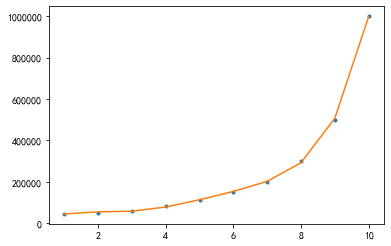

```python
X = df.iloc[:,1].values.reshape(-1,1)
y = df.iloc[:,2].values.reshape(-1,1)

X_poly = PolynomialFeatures(5).fit_transform(X)
linear = LinearRegression().fit(X_poly, y)

plt.plot(X, y, '.')
plt.plot(X, linear.predict(X_poly))
plt.show()
```

### 1.2 有偏回归：岭回归, LASSO, 弹性网

标准方程法: 直接求代价函数的全局最优解，时间复杂度O(n^3)，n=特征数量  
特征缩放: 使特征数值达到合适大小

1. 数据归一化Normalization:
   1. 取值(0, 1): Value = (Value - min) / (max - min)
   2. 取值(-1, 1): Value = ((Value - min)/(max - min)-0.5) * 2
2. 均值标准化Standardization (z-score)：
   1. 一般取值(-0.5, 0.5): Value = (Value - mean) / std

交叉验证法: 数据样本小，循环使每份数据都作训练集和测试集  
过拟合Overfitting: 模型过于复杂,训练集好,测试集差 (欠拟合,正确拟合)  
防止过拟合: 减少干扰特征, 增加数据量, 正则化  
正则化Regularization: L2正则化(加平方和), L1正则化(加绝对值和)  
**1.2.1 岭回归Ridge regression**: 最早用于解决数据特征比样本点多时不是满秩矩阵不可逆的问题, 代价函数L2正则化, 现在也用于在估计中加入偏差使更准确, 也可解决多重共线性的问题, 是一种有偏估计  
选择岭系数值使各回归系数的岭估计基本稳定, 残差平方和增大不多  
**1.2.2 LASSO**: 擅长处理多重共线性的数据, 也是有偏估计, 代价函数L1正则化, 会使某些(噪声)参数的系数等于零, 而岭回归只会接近于零  
**1.2.3 弹性网Elastic Net**: 岭回归和LASSO正则特点的结合

```python
df = pd.read_csv('longley.csv',index_col=0)
df.head()
```

|  | GNP.deflator | GNP | Unemployed | Armed.Forces | Population | Year | Employed |
| --- | --- | --- | --- | --- | --- | --- | --- |
| 1947 | 83.0 | 234.289 | 235.6 | 159.0 | 107.608 | 1947 | 60.323 |
| 1948 | 88.5 | 259.426 | 232.5 | 145.6 | 108.632 | 1948 | 61.122 |
| 1949 | 88.2 | 258.054 | 368.2 | 161.6 | 109.773 | 1949 | 60.171 |
| 1950 | 89.5 | 284.599 | 335.1 | 165.0 | 110.929 | 1950 | 61.187 |
| 1951 | 96.2 | 328.975 | 209.9 | 309.9 | 112.075 | 1951 | 63.221 |

```
Alpha of Ridge: 0.40875510204081633
Coefficient of Ridge: [ 0.21595168  0.02539448  0.00769513 -1.51557268 -0.39023809 -0.04027195]

Alpha of LASSO: 14.134043936116361
Coefficient of LASSO: [0.10093575 0.00586331 0.00599214 0.         0.         0.        ]

Alpha of Elastic Net: 30.310944054302677
Coefficient of Elastic Net: [0.1006612  0.00589596 0.00593021 0.         0.         0.        ]
```

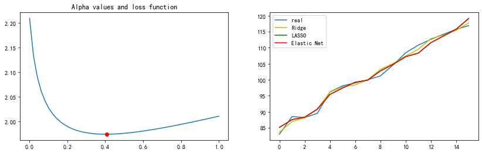

```python
X = df.iloc[:,1:]
y = df.iloc[:,0]
alphas_test = np.linspace(0.001, 1)

ridge = RidgeCV(alphas=alphas_test, store_cv_values=True).fit(X, y)
lasso = LassoCV().fit(X, y)
elastic = ElasticNetCV().fit(X, y)

print('Alpha of Ridge:', ridge.alpha_)
print('Coefficient of Ridge:', ridge.coef_)
print('\nAlpha of LASSO:', lasso.alpha_)
print('Coefficient of LASSO:', lasso.coef_)
print('\nAlpha of Elastic Net:', elastic.alpha_)
print('Coefficient of Elastic Net:', elastic.coef_)

plt.figure(figsize=(14,4))
plt.subplot(121)
plt.plot(alphas_test, ridge.cv_values_.mean(axis=0))
plt.plot(ridge.alpha_, min(ridge.cv_values_.mean(axis=0)), 'ro')
plt.title('Alpha values and loss function')

plt.subplot(122)
x = np.arange(len(y))
plt.plot(x, y, label='real')
plt.plot(x, ridge.predict(X), 'y', label='Ridge')
plt.plot(x, lasso.predict(X), 'g', label='LASSO')
plt.plot(x, elastic.predict(X), 'r', label='Elastic Net')
plt.legend()
plt.show()
```

## 2. 监督学习：分类算法

### 2.1 逻辑回归Logistic regression

适合处理二分类问题  
**2.1.1 线性逻辑回归**  
预测函数Sigmoid/Logistic function取值(0, 1), 决策边界Decision boundary为内函数等于零  
代价函数零值和一值分段, 不同于线性回归的代价函数, 也用梯度下降  
多分类问题转化为多次二分类, 也可正则化  
正确率与召回率(Precision & Recall), F1值(F-Score)是两者综合, 取值都在(0, 1), 越接近1效果越好

```python
df = pd.read_csv('LR-testSet.csv',header=None)
df.head()
```

|  | 0 | 1 | 2 |
| --- | --- | --- | --- |
| 0 | -0.017612 | 14.053064 | 0 |
| 1 | -1.395634 | 4.662541 | 1 |
| 2 | -0.752157 | 6.538620 | 0 |
| 3 | -1.322371 | 7.152853 | 0 |
| 4 | 0.423363 | 11.054677 | 0 |

```
Classification report:
              precision    recall  f1-score   support

           0       0.96      0.94      0.95        47
           1       0.94      0.96      0.95        53

    accuracy                           0.95       100
   macro avg       0.95      0.95      0.95       100
weighted avg       0.95      0.95      0.95       100

Score: 0.95
```

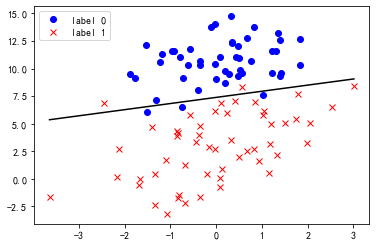

```python
X = df.iloc[:,:-1]
y = df.iloc[:,-1]

logi = LogisticRegression().fit(X, y)

print('Classification report:')
print(classification_report(y, logi.predict(X)))
print('Score:', logi.score(X, y))

plt.plot(X[y==0][0], X[y==0][1], 'bo', label='label 0')
plt.plot(X[y==1][0], X[y==1][1], 'rx', label='label 1')
plt.legend()

x_boundary = np.array([min(X[0]), max(X[0])])
y_boundary = (-logi.intercept_ - x_boundary*logi.coef_[0][0]) / logi.coef_[0][1]
plt.plot(x_boundary, y_boundary, 'k')
plt.show()
```

**2.1.2 非线性逻辑回归**: 提取多项式特征再用线性逻辑回归 (同多项式回归)

```python
df = pd.read_csv('LR-testSet2.txt',header=None)
df.head()
```

|  | 0 | 1 | 2 |
| --- | --- | --- | --- |
| 0 | 0.051267 | 0.69956 | 1 |
| 1 | -0.092742 | 0.68494 | 1 |
| 2 | -0.213710 | 0.69225 | 1 |
| 3 | -0.375000 | 0.50219 | 1 |
| 4 | -0.513250 | 0.46564 | 1 |

```
Classification report:
              precision    recall  f1-score   support

           0       0.90      0.77      0.83        60
           1       0.79      0.91      0.85        58

    accuracy                           0.84       118
   macro avg       0.85      0.84      0.84       118
weighted avg       0.85      0.84      0.84       118

Score: 0.8389830508474576
```

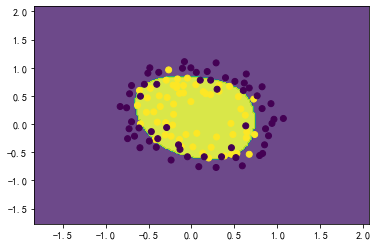

```python
X = df.iloc[:,:-1]
y = df.iloc[:,-1]

X_poly = PolynomialFeatures(5).fit_transform(X)
logi = LogisticRegression().fit(X_poly, y)

print('Classification report:')
print(classification_report(y, logi.predict(X_poly)))
print('Score:', logi.score(X_poly, y))

xx, yy = np.meshgrid(np.arange(min(X[0])-1, max(X[0])+1, 0.02),
                     np.arange(min(X[1])-1, max(X[1])+1, 0.02))

zz = np.c_[xx.ravel(), yy.ravel()]
zz_poly = PolynomialFeatures(5).fit_transform(zz)
zz_predict = logi.predict(zz_poly).reshape(xx.shape)

plt.contourf(xx, yy ,zz_predict, alpha=0.8)
plt.scatter(X[0], X[1], c=y)
plt.show()
```

### 2.2 KNN(K-Nearest Neighbor)

最近邻规则分类, 用欧式距离Euclidean distance  
k值一般取单数, 算法复杂度较高, 样本分布不平衡时 (某一样本过大)可能不准确

```python
iris = datasets.load_iris()
X = iris.data
y = iris.target
X_train, X_test, y_train, y_test = train_test_split(X, y, test_size=0.3)

knn = KNeighborsClassifier().fit(X_train, y_train)

print('Classification report:')
print(classification_report(y_test, knn.predict(X_test)))
print('Score:', knn.score(X_test, y_test))
```

```
Classification report:
              precision    recall  f1-score   support

           0       1.00      1.00      1.00        20
           1       1.00      0.91      0.95        11
           2       0.93      1.00      0.97        14

    accuracy                           0.98        45
   macro avg       0.98      0.97      0.97        45
weighted avg       0.98      0.98      0.98        45

Score: 0.9777777777777777
```

### 2.3 决策树Decision tree

适合分析离散数据 (连续数据先转成离散)  
信息熵Entropy: 对不确定性的度量, 信息熵越大, 不确定性越高  
ID3算法: 根据信息增益最大化来划分决策树的节点, 信息增益最大的作为根节点, 处理连续变量时以信息增益最大化来划分阈值,并转化为离散变量  
**2.3.1 C4.5算法**: 引入增益率求信息增益比, 以改进ID3方法倾向于选择因子数较多的变量的问题

```python
df = pd.read_csv('AllElectronics.csv', index_col=0)
df.head()
```

| RID | age | income | student | credit_rating | class_buys_computer |
| --- | --- | --- | --- | --- | --- |
| 1 | youth | high | no | fair | no |
| 2 | youth | high | no | excellent | no |
| 3 | middle_aged | high | no | fair | yes |
| 4 | senior | medium | no | fair | yes |
| 5 | senior | low | yes | fair | yes |

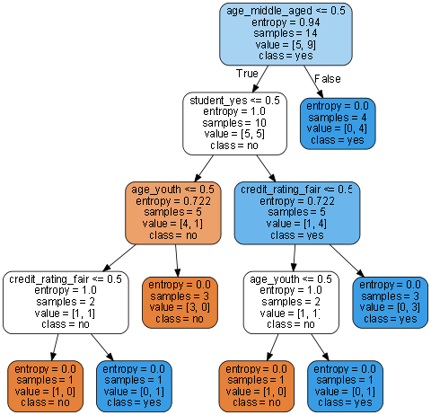

```python
X = pd.get_dummies(df.iloc[:,:-1])
y = df.iloc[:,-1]

dtree = DecisionTreeClassifier(criterion='entropy').fit(X,y)

dot = export_graphviz(dtree, feature_names=X.columns, class_names=y.unique(), filled=True, rounded=True)
graph = pyd.graph_from_dot_data(dot)
graph.set_size("5,5!")
Image(graph.create_png())
```

**2.3.2 CART算法**: 根据基尼不纯度Gini最小化来进行特征选择, 递归地构建二叉决策树, 基尼系数增益值最大的属性为根节点属性, 对小规模数据集有效

```python
df = pd.read_csv('cart.csv', index_col=0)
df.head()
```

| RID | house_yes | house_no | single | married | divorced | income | label |
| --- | --- | --- | --- | --- | --- | --- | --- |
| 1 | 1 | 0 | 1 | 0 | 0 | 125 | 0 |
| 2 | 0 | 1 | 0 | 1 | 0 | 100 | 0 |
| 3 | 0 | 1 | 1 | 0 | 0 | 70 | 0 |
| 4 | 1 | 0 | 0 | 1 | 0 | 120 | 0 |
| 5 | 0 | 1 | 0 | 0 | 1 | 95 | 1 |

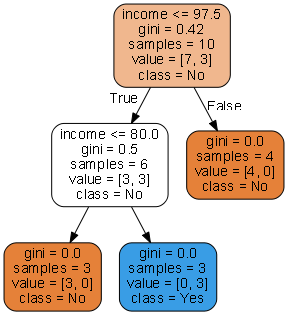

```python
X = df.iloc[:,:-1]
y = df.iloc[:,-1]

dtree = DecisionTreeClassifier().fit(X,y)

dot = export_graphviz(dtree, feature_names=X.columns, class_names=['No','Yes'], filled=True, rounded=True)
graph = pyd.graph_from_dot_data(dot)
graph.set_size("3,5!")
Image(graph.create_png())
```

**2.3.3 剪枝Pruning**: 包括预剪枝和后剪枝, 减少节点, 降低算法复杂度, 防止过拟合

```python
def plotLr(model,title,a):
    print(f'Score for {title}: {model.score(X_test, y_test)}')
    xx, yy = np.meshgrid(np.arange(min(X[0])-1, max(X[0])+1, 0.02),
                         np.arange(min(X[1])-1, max(X[1])+1, 0.02))
    zz_predict = model.predict(np.c_[xx.ravel(), yy.ravel()]).reshape(xx.shape)
    plt.subplot(a)
    plt.title(title)
    plt.contourf(xx, yy ,zz_predict, alpha=0.8)
    plt.scatter(X[0], X[1], c=y)
```

```
Score of train: 1.0
Score for Non-pruning: 0.8
Score of train: 0.8522727272727273
Score for Pruning: 0.7666666666666667
```

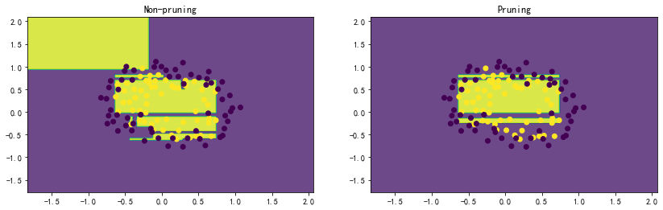

```python
df = pd.read_csv('LR-testSet2.txt',header=None)
X = df.iloc[:,:-1]
y = df.iloc[:,-1]
X_train, X_test, y_train, y_test = train_test_split(X, y)

dtree = DecisionTreeClassifier().fit(X_train, y_train)
pruning_dtree = DecisionTreeClassifier(max_depth=6,min_samples_split=4).fit(X_train, y_train)

plt.figure(figsize=(14,4))
print('Score of train:', dtree.score(X_train, y_train))
plotLr(dtree,'Non-pruning',121)
print('Score of train:', pruning_dtree.score(X_train, y_train))
plotLr(pruning_dtree,'Pruning',122)
```

### 2.4 朴素贝叶斯Naive bayes

适合对文本数据的分析, 使用先验概率, 贝叶斯算法在有多个特征的情况下会使统计量巨大, 朴素贝叶斯就是假定特征之间相互独立  
**2.4.1 伯努利模型Bernoulli**不考虑重复词语，**多项式模型Multinomial**考虑重复词语，混合模型训练时考虑测试时不考虑，**高斯模型Gaussian**适合处理连续变量

```python
iris = datasets.load_iris()
X_train, X_test, y_train, y_test = train_test_split(iris.data, iris.target)

ber_nb = BernoulliNB().fit(X_train, y_train)
mul_nb = MultinomialNB().fit(X_train, y_train)
gau_nb = GaussianNB().fit(X_train, y_train)

print('BernoulliNB score:', ber_nb.score(X_test, y_test))
print('Confusion matrix:\n',confusion_matrix(y_test, ber_nb.predict(X_test)))
print('\nMultinomialNB score:', mul_nb.score(X_test, y_test))
print('Confusion matrix:\n',confusion_matrix(y_test, mul_nb.predict(X_test)))
print('\nGaussianNB score:', gau_nb.score(X_test, y_test))
print('Confusion matrix:\n',confusion_matrix(y_test, gau_nb.predict(X_test)))
```

```
BernoulliNB score: 0.2631578947368421
Confusion matrix:
 [[10  0  0]
 [14  0  0]
 [14  0  0]]

MultinomialNB score: 0.9210526315789473
Confusion matrix:
 [[10  0  0]
 [ 0 12  2]
 [ 0  1 13]]

GaussianNB score: 0.9473684210526315
Confusion matrix:
 [[10  0  0]
 [ 0 14  0]
 [ 0  2 12]]
```

**2.4.2 词袋模型Bag of words**: 用一组无序的单词来表达一段文本, 显示单词和出现次数, 把文本数据用CountVectorizer矢量化再使用模型, 也可过滤停用词

```python
def printBow(i):
    word = cv.get_feature_names()[order[i]]
    freq = count_total[order[i]]
    print(f'No.{i+1}: The word [{word}] occurs [{freq}] times.')
```

```python
news = datasets.fetch_20newsgroups(subset='all')
X, y = news.data[:3000], news.target[:3000]

cv = CountVectorizer(stop_words='english')
X_cv = cv.fit_transform(X)
count_total = X_cv.toarray().sum(axis=0)
order = np.argsort(-count_total)
print('In 3000 news (frequency):')
for i in range(5): printBow(i)

X_train, X_test, y_train, y_test = train_test_split(X, y)
X_train_cv = cv.transform(X_train)
X_test_cv = cv.transform(X_test)
mul_nb = MultinomialNB().fit(X_train_cv, y_train)
print('\nScore for train:',mul_nb.score(X_train_cv, y_train))
print('Score for test:',mul_nb.score(X_test_cv, y_test))
```

```
In 3000 news (frequency):
No.1: The word [edu] occurs [5835] times.
No.2: The word [ax] occurs [4931] times.
No.3: The word [com] occurs [3299] times.
No.4: The word [subject] occurs [3213] times.
No.5: The word [lines] occurs [3148] times.

Score for train: 0.9888888888888889
Score for test: 0.78
```

**2.4.3 TF-IDF算法**: 提取词频Term Frequency(TF), 过滤停用词Stop words, 再以逆文档频率Inverse Document Frequency(IDF)作为权重, IDF与词的常见程度成反比, 将TF和IDF相乘得到词的重要性, 用TfidfVectorizer完成向量化和TFIDF处理

```python
def printTf(i):
    weight = X_tf.toarray()[i]
    order = np.argsort(-weight)
    word_list = []
    for j in range(5):
        word = tf.get_feature_names()[order[j]]
        word_list.append(word)
    print(f'In news {i+1}: {word_list}')

def printCv(i):
    count = X_cv.toarray()[i]
    order = np.argsort(-count)
    word_list = []
    for j in range(5):
        word = cv.get_feature_names()[order[j]]
        word_list.append(word)
    print(f'In news {i+1}: {word_list}')
```

```python
news = datasets.fetch_20newsgroups(subset='all')
X, y = news.data[:3000], news.target[:3000]

tf = TfidfVectorizer(stop_words='english')
X_tf = tf.fit_transform(X)
print('Top 5 key words (TFIDF):')
for i in range(5): printTf(i)
print('\nTop 5 key words (frequency):')
for i in range(5): printCv(i)

X_train, X_test, y_train, y_test = train_test_split(X, y)
X_train_tf = tf.transform(X_train)
X_test_tf = tf.transform(X_test)
mul_nb = MultinomialNB().fit(X_train_tf, y_train)
print('\nScore for train:',mul_nb.score(X_train_tf, y_train))
print('Score for test:',mul_nb.score(X_test_tf, y_test))
```

```
Top 5 key words (TFIDF):
In news 1: ['pens', 'jagr', 'devils', 'fans', 'bit']
In news 2: ['vlb', 'uoknor', 'ecn', 'nebuchadnezzar', 'mblawson']
In news 3: ['hilmi', 'armenia', 'elchibey', 'announced', 'weapons']
In news 4: ['bus', 'dma', 'scsi', 'data', 'transfers']
In news 5: ['jasmine', 'inexpensive', 'drive', 'utility', 'tape']

Top 5 key words (frequency):
In news 1: ['pens', 'bit', 'going', 'regular', 'cmu']
In news 2: ['card', 'vlb', 'video', 'edu', 'uoknor']
In news 3: ['weapons', 'armenia', 'turkish', 'armenians', 'hilmi']
In news 4: ['bus', 'data', 'scsi', 'dma', 'ibm']
In news 5: ['drive', 'use', 'utility', 'cmu', 'driver']

Score for train: 0.9733333333333334
Score for test: 0.7493333333333333
```

### 2.5 支持向量机SVM(Support Vector Machines)

适合图像识别等复杂分类情况, SVM寻找区分两类的超平面Hyper plane使边际Margin最大, 是深度学习 (2012) 出现前最好的算法  
**2.5.1 线性可分情况**  
运算转化为凸优化问题: 1.无约束优化问题, 费马定理 2.带等式约束的优化问题, 拉格朗日乘子法 3.带不等式约束的优化问题, KKT条件 (拉格朗日乘子法的推广)  
拉格朗日乘子法进一步转化为对偶问题, 使用SMO算法优化

```
Some support vectors:
 [[-0.752157  6.53862 ]
 [-1.322371  7.152853]
 [-0.397822  8.058397]
 [ 1.015399  7.571882]
 [-1.510047  6.061992]]
Index of the support vectors: [ 2  3 52 75 80]
Number of support vectors (on each side): [6 6]
```

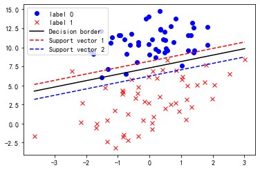

```python
df = pd.read_csv('LR-testSet.csv',header=None)
X, y = df.iloc[:,:-1], df.iloc[:,-1]

svc = SVC(kernel='linear').fit(X, y)
print('Some support vectors:\n', svc.support_vectors_[:5])
print('Index of the support vectors:', svc.support_[:5])
print('Number of support vectors (on each side):', svc.n_support_)

x = np.array([min(X[0]), max(X[0])])
k = -svc.coef_[0][0]/svc.coef_[0][1]
d = -svc.intercept_/svc.coef_[0][1]
y_bountry = k*x + d

v1 = svc.support_vectors_[5]
v2 = svc.support_vectors_[-1]
y_v1 = k*x + (v1[1] - k*v1[0])
y_v2 = k*x + (v2[1] - k*v2[0])

plt.plot(X[y==0][0], X[y==0][1], 'bo', label='label 0')
plt.plot(X[y==1][0], X[y==1][1], 'rx', label='label 1')
plt.plot(x, y_bountry, 'k', label='Decision border')
plt.plot(x, y_v1, 'r--', label='Support vector 1')
plt.plot(x, y_v2, 'b--', label='Support vector 2')
plt.legend()
plt.show()
```

线性不可分情况时: 引入松弛变量Slack variable和惩罚函数Penalty function  
使分错的点越少越好, 距离分类边界越近越好, 改进线性不可分情况下的对偶问题  
**2.5.2 非线性情况时**: 把低维空间的非线性问题映射到高维空间, 变成求解线性问题  
可能导致维度灾难大幅增加运算时间, 引入核函数解决非线性映射: h次多项式核函数, 高斯径向基函数核函数, S型核函数  
SVM优点: 1. 模型的算法复杂度取决于支持向量个数不容易过拟合 2.模型完全依赖于支持向量不依赖其余非支持向量 3.如果训练得出支持向量数量少模型容易被范化

```
Score of train: 0.8409090909090909
Score for SVC: 0.7666666666666667
```

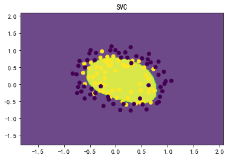

```python
df = pd.read_csv('LR-testSet2.txt',header=None)
X = df.iloc[:,:-1]
y = df.iloc[:,-1]
X_train, X_test, y_train, y_test = train_test_split(X, y)

svc = SVC().fit(X_train, y_train)
print('Score of train:', svc.score(X_train, y_train))
plotLr(svc,'SVC',111)
```

### 2.6 神经网络Neural network

即深度学习Deep learning, 近年随大数据算力算法而迅速发展  
单层感知器SLP(Single Layer Perceptron): 不能解决非线性问题如异或问题  
线性神经网络: 结构与感知器相似, 激活函数由sign函数改为线性purelin函数 (y=x), 引入非线性项可解决异或问题  
Delta学习规则: 利用梯度下降法的连续感知器学习规则  
BP神经网络(Back Propagation Neural Network): 误差反向传播, 解决了多层神经网络的学习问题, 网络结构包括输入层, 隐藏层和输出层  
常见激活函数Activation function: Sigmoid函数(逻辑回归函数)(0,1), Tanh函数(双曲正切函数)(-1,1), Softsign函数(比Tanh平滑)(-1,1), ReLU函数(线性整流函数)(最常用)  
**多层感知器MLP(Multi Layer Perceptron)**: 应用BP算法, 包含隐藏层

```python
digits = datasets.load_digits()
X, y = digits.data, digits.target

X = StandardScaler().fit_transform(X)
X_train, X_test, y_train, y_test = train_test_split(X, y)

mlp = MLPClassifier().fit(X_train, y_train)

print('Confusion matrix:')
print(confusion_matrix(y_test, mlp.predict(X_test)))
print('\nClassification report:')
print(classification_report(y_test, mlp.predict(X_test)))
```

```
Confusion matrix:
[[40  0  0  0  0  0  0  0  0  0]
 [ 0 41  0  0  0  0  0  0  0  0]
 [ 0  0 47  1  0  0  0  0  0  0]
 [ 0  0  0 39  0  0  0  0  1  1]
 [ 0  0  0  0 42  0  0  1  0  1]
 [ 0  0  0  0  0 45  0  0  0  1]
 [ 0  0  0  0  1  0 40  0  1  0]
 [ 0  0  0  0  0  0  0 47  0  1]
 [ 0  3  1  2  0  0  0  0 54  0]
 [ 0  0  0  0  0  1  0  0  2 37]]

Classification report:
              precision    recall  f1-score   support

           0       1.00      1.00      1.00        40
           1       0.93      1.00      0.96        41
           2       0.98      0.98      0.98        48
           3       0.93      0.95      0.94        41
           4       0.98      0.95      0.97        44
           5       0.98      0.98      0.98        46
           6       1.00      0.95      0.98        42
           7       0.98      0.98      0.98        48
           8       0.93      0.90      0.92        60
           9       0.90      0.93      0.91        40

    accuracy                           0.96       450
   macro avg       0.96      0.96      0.96       450
weighted avg       0.96      0.96      0.96       450
```

### 2.7 集成学习Ensemble learning

组合多个学习器以得到一个更好的学习器  
**2.7.1 装袋Bagging**: 也叫Bootstrap aggregating, 是一种有放回抽样, 分出多组数据分别使用模型并组合投票, 适合复杂的数据, 个体学习器之间不存在强依赖关系

```python
def plotIris(model,title,a):
    print(f'Score for {title}: {model.score(X_test, y_test)}')
    xx, yy = np.meshgrid(np.arange(min(X[:,0])-1, max(X[:,0])+1, 0.02),
                         np.arange(min(X[:,1])-1, max(X[:,1])+1, 0.02))
    zz_predict = model.predict(np.c_[xx.ravel(), yy.ravel()]).reshape(xx.shape)
    plt.subplot(a)
    plt.title(title)
    plt.contourf(xx, yy ,zz_predict)
    plt.scatter(X[:,0], X[:,1], c=y)
```

```
Score for knn: 0.8
Score for bagging knn: 0.8
Score for dtree: 0.6
Score for bagging dtree: 0.6444444444444445
```

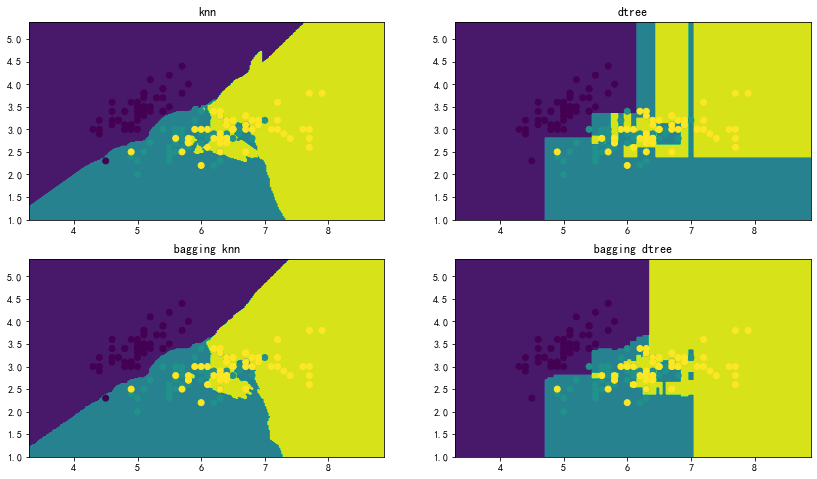

```python
iris = datasets.load_iris()
X = iris.data[:,:2]
y = iris.target
X_train, X_test, y_train, y_test = train_test_split(X, y, test_size=0.3)

knn = KNeighborsClassifier().fit(X_train, y_train)
dtree = DecisionTreeClassifier().fit(X_train, y_train)
bagging_knn = BaggingClassifier(knn, n_estimators=100).fit(X_train, y_train)
bagging_dtree = BaggingClassifier(dtree, n_estimators=100).fit(X_train, y_train)

plt.figure(figsize=(14,8))
plotIris(knn,'knn',221)
plotIris(bagging_knn,'bagging knn',223)
plotIris(dtree,'dtree',222)
plotIris(bagging_dtree,'bagging dtree',224)
```

**2.7.2 随机森林Random forest**: RF=决策树+Bagging+随机属性选择, 用bagging随机产生样本, 再随机选择特征建立CART决策树, 多颗决策树构成随机森林并投票表决结果, 一般比单一决策树准确

```
Score for dtree: 0.8666666666666667
Score for RF: 0.8666666666666667
```

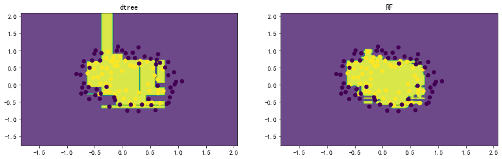

```python
df = pd.read_csv('LR-testSet2.txt',header=None)
X = df.iloc[:,:-1]
y = df.iloc[:,-1]
X_train, X_test, y_train, y_test = train_test_split(X, y)

dtree = DecisionTreeClassifier().fit(X_train, y_train)
RF = RandomForestClassifier().fit(X_train, y_train)

plt.figure(figsize=(14,4))
plotLr(dtree,'dtree',121)
plotLr(RF,'RF',122)
```

**2.7.3 自适应增强Adaboost** (提升算法boosting): 抽样时增大被前一弱分类器错误分类的样本的权值, 引入并训练下一弱分类器, 直到达到预定错误率或最大迭代次数时才确定最终的强分类器, 在强分类器中加大错误率低的弱分类器的权重, 个体分类器之间存在强依赖关系

```
Score for dtree: 0.7666666666666667
Score for adaboost: 0.7666666666666667
```

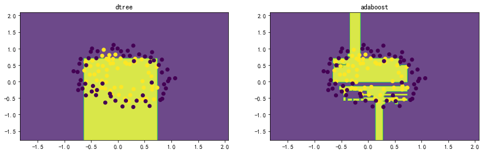

```python
df = pd.read_csv('LR-testSet2.txt',header=None)
X = df.iloc[:,:-1]
y = df.iloc[:,-1]
X_train, X_test, y_train, y_test = train_test_split(X, y)

dtree = DecisionTreeClassifier(max_depth=3).fit(X_train, y_train)
adaboost = AdaBoostClassifier(dtree).fit(X_train, y_train)

plt.figure(figsize=(14,4))
plotLr(dtree,'dtree',121)
plotLr(adaboost,'adaboost',122)
```

**2.7.4 Stacking**: 使用多个不同分类器对训练集进行预测, 把预测结果输入一个次级分类器再输出得到最终预测结果  
**Voting**: 对不同分类器的预测结果直接投票, 没有次级分类器

```python
def plotIrisCV(model,title,a):
    score = cross_val_score(model, X, y, cv=3).mean()
    print(f'CV Score for {title}: {score}')
    xx, yy = np.meshgrid(np.arange(min(X[:,0])-1, max(X[:,0])+1, 0.02),
                         np.arange(min(X[:,1])-1, max(X[:,1])+1, 0.02))
    zz_predict = model.predict(np.c_[xx.ravel(), yy.ravel()]).reshape(xx.shape)
    plt.subplot(a)
    plt.title(title)
    plt.contourf(xx, yy ,zz_predict)
    plt.scatter(X[:,0], X[:,1], c=y)
```

```
CV Score for knn: 0.9066666666666667
CV Score for dtree: 0.9133333333333334
CV Score for logi: 0.9533333333333333
CV Score for gau_nb: 0.9133333333333334
CV Score for stacking: 0.9333333333333332
CV Score for voting: 0.94
```

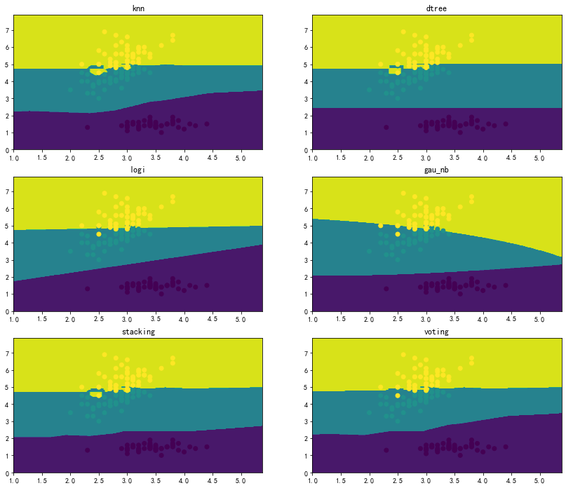

```python
iris = datasets.load_iris()
X = iris.data[:,1:3]
y = iris.target

knn = KNeighborsClassifier(n_neighbors=1).fit(X, y)
dtree = DecisionTreeClassifier().fit(X, y)
logi = LogisticRegression().fit(X, y)
gau_nb = GaussianNB().fit(X, y)

stacking = StackingClassifier([knn,dtree,logi,gau_nb], logi).fit(X, y)
voting = VotingClassifier([('1',knn),('2',dtree),('3',logi),('4',gau_nb)]).fit(X, y)

plt.figure(figsize=(14,12))
plotIrisCV(knn,'knn',321)
plotIrisCV(dtree,'dtree',322)
plotIrisCV(logi,'logi',323)
plotIrisCV(gau_nb,'gau_nb',324)
plotIrisCV(stacking,'stacking',325)
plotIrisCV(voting,'voting',326)
```

## 3. 无监督学习：聚类及降维算法

### 3.1 K-Means

**3.1.1 标准K-Means**: 以随机k个点为中心进行聚类, 将靠近的对象归类, 逐次迭代更新各聚类中心的值, 直到聚类结果不再发生变化 (基于距离)

```python
data = np.genfromtxt('kmeans.txt')
data[:5]
```

```
array([[ 1.658985,  4.285136],
       [-3.453687,  3.424321],
       [ 4.838138, -1.151539],
       [-5.379713, -3.362104],
       [ 0.972564,  2.924086]])
```

```
Cluster centers:
 [[ 2.6265299   3.10868015]
 [-3.38237045 -2.9473363 ]
 [ 2.80293085 -2.7315146 ]
 [-2.46154315  2.78737555]]
```

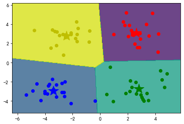

```python
kmeans = KMeans(4).fit(data)
result = kmeans.predict(data)
centers = kmeans.cluster_centers_
print('Cluster centers:\n', centers)

mark = ['or', 'ob', 'og', 'oy']
for i,d in enumerate(data):
    plt.plot(d[0], d[1], mark[result[i]])

mark = ['*r', '*b', '*g', '*y']
for i,center in enumerate(centers):
    plt.plot(center[0], center[1], mark[i], markersize=20)

xx, yy = np.meshgrid(np.arange(min(data[:,0])-1, max(data[:,0])+1, 0.02),
                     np.arange(min(data[:,1])-1, max(data[:,1])+1, 0.02))
zz = kmeans.predict(np.c_[xx.ravel(), yy.ravel()]).reshape(xx.shape)
plt.contourf(xx, yy ,zz, alpha=0.8)
plt.show()
```

K-Means缺点: 1.对初始质心比较敏感容易陷入局部最小值 2.需要用户自己选择合适的k值 3.只能根据距离分类, 不能处理密度分布的数据 4.数据量大时收敛较慢  
优化1: 使用多次随机初始化并计算每次建模的代价函数, 取代价函数最小结果为聚类结果  
优化2: 使用肘部法则选择k值 (观察代价函数关于k值的图像)  
优化3: 使用DBSCAN  
优化4: 使用Mini Batch K-means  
**3.1.2 Mini Batch K-means**: 是K-means的变种, 每次只抽取小的数据子集进行训练, 大大减少了计算时间, 结果一般只略差于标准算法, 适合大数据量的情况

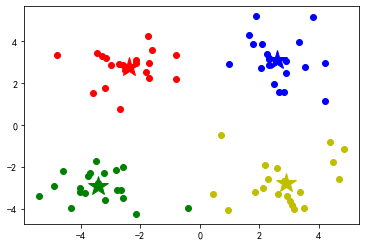

```python
data = np.genfromtxt('kmeans.txt')
kmeansMini = MiniBatchKMeans(4).fit(data)

mark = ['or', 'ob', 'og', 'oy']
for i,d in enumerate(data):
    plt.plot(d[0], d[1], mark[kmeansMini.predict(data)[i]])

mark = ['*r', '*b', '*g', '*y']
for i,center in enumerate(kmeansMini.cluster_centers_):
    plt.plot(center[0], center[1], mark[i], markersize=20)
```

### 3.2 DBSCAN

将具有足够高密度的区域划分为簇, 并可以发现任何形状的聚类 (基于密度)  
指定合适的Epsilon和Minpoints, 若点p的E领域有超过Minpoints个点则创建以p为核心点的新簇, 将核心点直接密度可达或密度可达的点加入相应的簇, 合并核心点密度相连的簇, 当没有新的点能被添加到任何簇时算法结束  
缺点: 数据量大时要求较大内存支持和I/O消耗, 聚类的密度不均匀聚类间距差相差大时效果较差  
优点: 不需要输入聚类个数, 聚类簇的形状没有要求, 可以输入过滤噪声的参数(Epsilon和Minpoints)

```
Noise ratio: 0.60%
Estimated number of clusters: 3
```

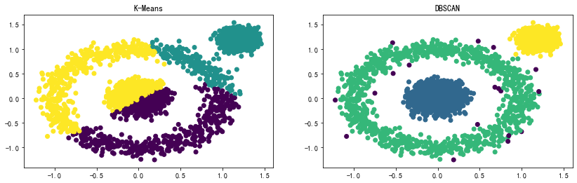

```python
x1, y1 = datasets.make_circles(2000, factor=0.2, noise=0.1)
x2, y2 = datasets.make_blobs(1000, centers=[[1.2,1.2]], cluster_std=0.1)
x = np.concatenate((x1, x2))

y_kmeans = KMeans(3).fit_predict(x)
y_dbscan = DBSCAN(eps=0.2, min_samples=50).fit_predict(x)

ratio = len(y_dbscan[y_dbscan[:]==-1]) / len(y_dbscan)
clusters = len(set(y_dbscan)) - (1 if -1 in y_dbscan else 0)
print('Noise ratio:', format(ratio,'.2%'))
print('Estimated number of clusters: %d'% clusters)

plt.figure(figsize=(14,4))
plt.subplot(121)
plt.title('K-Means')
plt.scatter(x[:,0], x[:,1], c=y_kmeans)
plt.subplot(122)
plt.title('DBSCAN')
plt.scatter(x[:,0], x[:,1], c=y_dbscan)
plt.show()
```

### 3.3 主成分分析PCA(Principal Component Analysis)

是一种降维算法, 可用于多维数据的可视化, 找到数据最重要的方向并作投影  
数据预处理(中心化), 求样本的协方差矩阵并做特征值分解, 选出最大的k个特征值对应的k个特征向量, 并将原始数据投影到选取的特征向量上  
方差描述离散程度, 协方差描述相关性: 接近1正相关, 接近-1负相关, 接近0不相关

```
Data shape: (150, 4)
```

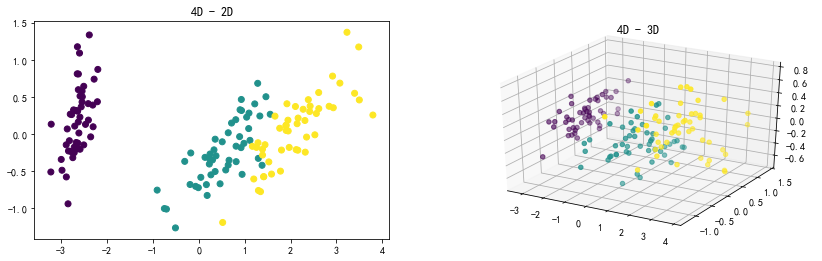

```python
iris = datasets.load_iris()
X, y = iris.data, iris.target
print('Data shape:', X.shape)

X_2d = PCA(2).fit_transform(X)
X_3d = PCA(3).fit_transform(X)

fig = plt.figure(figsize=(14,4))
ax = fig.add_subplot(121)
ax.scatter(X_2d[:,0], X_2d[:,1], c=y)
plt.title('4D - 2D')

ax = fig.add_subplot(122, projection='3d')
ax.scatter(X_3d[:,0], X_3d[:,1], X_3d[:,2], c=y)
plt.title('4D - 3D')
plt.show()
```